# ProyectoTD2022

Tratamiento de Datos. Grado en Ciencia de Datos- UV

Grupo H: Salvador Gisbert Sempere, Jorge Albalat Luengo, Maite García Falcón, Aina Rosas Soler, Rosa Martínez Enrich

2022-05-16

# 1 Configuración de los bloques (*Chunks*)

# 2 Instalación automática de paquetes

Especificar las librerías necesarias para ejecutar el código en la variable *packages*. Si no está instaladas, se instalarán y cargarán (solo para aquellas que están en el repositorio http://cran.rediris.es)

El siguiente bloque, al no especificar opciones del *chunk* usa la configuración por defecto.

## 2.1 Introducción:

El objetivo de este proyecto es que nos enfrentemos a un problema de tratamiento de datos que abarque todas las etapas que estamos describiendo a lo largo del curso. Analizaremos los datos recogidos por sensores que monitorizan el nivel de ruido en diferentes localizaciones del barrio de Ruzafa.

# 3 Importación de los datos

Para comenzar a analizar los datos, debemos primero importarlos. Los importaremos de internet para que así estén actualizados constantemente de manera automática. De este modo, cada vez que iniciemos el código se va a descargar desde la URL.

# 4 Unión data frames en uno solo

## 4.1 Analisis inicial de los datos.

```
     ï.._id         recvTime         fiwareServicePath   entityType          entityId
 Min.   :   1.0   Length:6905        Length:6905        Length:6905        Length:6905
 1st Qu.: 124.0   Class :character   Class :character   Class :character   Class :character
 Median : 247.0   Mode  :character   Mode  :character   Mode  :character   Mode  :character
 Mean   : 426.8
 3rd Qu.: 822.0
 Max.   :1035.0
      LAeq           LAeq_d        LAeq_den         LAeq_e         LAeq_n      dateObserved
 Min.   :49.60   Min.   :51.3   Min.   :52.60   Min.   :46.3   Min.   :40.10   Length:6905
 1st Qu.:58.60   1st Qu.:59.6   1st Qu.:61.50   1st Qu.:57.9   1st Qu.:51.50   Class :character
 Median :60.40   Median :61.7   Median :63.40   Median :60.2   Median :54.20   Mode  :character
 Mean   :60.79   Mean   : Inf   Mean   :64.05   Mean   : Inf   Mean   :54.82
 3rd Qu.:62.10   3rd Qu.:63.3   3rd Qu.:65.90   3rd Qu.:63.2   3rd Qu.:57.70
 Max.   :91.30   Max.   : Inf   Max.   :96.40   Max.   : Inf   Max.   :90.00
      c
 Length:6905
 Class :character
 Mode  :character
```

```
Rows: 6,905
Columns: 12
$ ï.._id            <int> 1, 2, 3, 4, 5, 6, 7, 8, 9, 10, 11, 12, 13, 14, 15, 16, 17, 18, 19, 20, 2~
$ recvTime          <chr> "2020-11-18T13:40:52.283Z", "2020-11-19T00:00:03.394Z", "2020-11-20T00:0~
$ fiwareServicePath <chr> "/sonometros", "/sonometros", "/sonometros", "/sonometros", "/sonometros~
$ entityType        <chr> "NoiseLevelObserved", "NoiseLevelObserved", "NoiseLevelObserved", "Noise~
$ entityId          <chr> "T248655-daily", "T248655-daily", "T248655-daily", "T248655-daily", "T24~
$ LAeq              <dbl> 64.7, 64.4, 64.3, 65.0, 64.5, 62.5, 63.9, 65.5, 64.4, 64.2, 64.7, 63.2, ~
$ LAeq_d            <dbl> 66.4, 65.9, 66.0, 66.4, 65.8, 63.8, 65.5, 67.3, 66.1, 65.7, 66.2, 64.1, ~
$ LAeq_den          <dbl> 67.0, 67.6, 66.8, 68.1, 68.0, 66.1, 66.4, 67.8, 67.1, 67.2, 67.7, 67.5, ~
$ LAeq_e            <dbl> 64.0, 64.7, 63.8, 66.3, 65.9, 63.6, 64.0, 64.1, 64.4, 64.1, 65.1, 65.1, ~
$ LAeq_n            <dbl> 57.2, 59.0, 57.5, 59.2, 59.7, 58.0, 57.0, 58.1, 57.8, 58.5, 59.0, 59.9, ~
$ dateObserved      <chr> "2020-11-17", "2020-11-18", "2020-11-19", "2020-11-20", "2020-11-21", "2~
$ c                 <chr> "Cadiz_3", "Cadiz_3", "Cadiz_3", "Cadiz_3", "Cadiz_3", "Cadiz_3", "Cadiz~
```

## 4.2 Preguntas propuestas

1. ¿Cuántas variables o columnas tiene el data frame?
2. ¿Los datos son fácilmente accesibles?
3. ¿Que datos podemos observar en este data frame?
4. ¿Hay datos perdidos?¿Es un analisis univariante o bivariante?
5. ¿Cómo varía el ruido durante el día a partir de las siete (de 7 a 19, de 19 a 23 y de 23 a 7) durante los meses dividido en años?
6. En la pregunta anterior, determina cuál es el mes en el que más ruido hay, ¿Cómo se mide el ruido durante las diferentes franjas horarias del dia en ese mes?
7. ¿Qué calle alcanzó mayor nivel sonoro durante los diferentes años registrados? ¿Y la que menos?
8. ¿Cuál ha sido el año en el que se ha producido de media más ruido?
9. El nivel sonoro en la tarde-noche representa la molestia que produce, ¿en qué mes hubo mayor malestar en el 2021?¿y en cuál menos?

# 5 Acondicionamiento en tidy dataset

## 5.1 Datos no variables

Comprobamos los datos que no varían y eliminamos las columnas.

## 5.2 Nombres de las columnas

Renombramos las columnas con el fin de manejarlas más fácilmente y de que tengan un nombre más representativo.

## 5.3 Tipos de las variables

Como hemos visto anteriormente en el análisis inicial de los datos, debemos cambiar la columna ahora llamada tiempo_grabacion a tipo factor, y la variable fecha_observacion a tipo fecha.

## 5.4 Datos faltantes

Vamos a ver si existen datos faltantes(NA) por si hay que corregirlos.

```
[1] 0
```

Como no existen datos faltantes(NA) no hace falta corregir nada.

## 5.5 Valores infinitos

Hemos observado que existen valores infinitos en el maximo de r_7_19 y en r_19_23, así que vamos a imputar sus valores como el máximo de los demás:

```
[1] Inf
```

```
[1] Inf
```

```
   id         tiempo_grabacion r_continuo r_7a19 r_tardenoche r_19a23 r_23a7 fecha_observacion
1 198 2021-04-30T00:00:24.667Z       61.9   63.7         63.0     Inf   51.5        2021-04-29
2 126 2021-03-04T00:00:57.749Z       52.6    Inf         60.9    52.4   52.8        2021-03-03
                                   calle
1                               Cadiz_16
2 SalvadorAbril_Chaf_Maestro_JoseSerrano
```

Procedemos a imputar los datos que sean infinitos al máximo de todos los que no lo son, ya que no es eficiente eliminarlos.

## 5.6 Fecha Observación

Separamos la fecha de observación en 3 columnas (año, mes y día).

Las convertimos en factor.

## 5.7 Clasificación por franja horaria.

Finalmente para que sea un correcto tidy dataset debemos definir el nivel de sonoridad en las horas en las que hemos grabado.

# 6 Estadísticos, análisis, manipulación…

Finalmente, en esta fase nos dispondremos a analizar los datos de manera que podamos obtener la máxima información posible.

## 6.1 Análisis Univariante

Comenzaremos esta fase con el análisis univariante. De este modo podremos conocer cómo se comportan nuestras variables.

Primero calcularemos la media del nivel sonoro.

Como podemos observar, la media del nivel sonoro en todas las calles es de 60.4798001 dBA.

Seguidamente calcularemos la mediana de la misma variable.

Así pues, podemos decir que la mediana del nivel sonoro es 60.6 dBA.

Podemos también calcular el rango para saber cuál es la diferencia entre el ruido más alto registrado y el más bajo. Aprovecharemos esto y calcularemos también el mínimo y el máximo. De este modo obtendremos el ruido más bajo registrado y el más alto.

Tras estos cálculos observamos como el ruido más alto registrado se situó en 97.4 dBA, en cambio el ruido más bajo rozó los 40.1 dBA. Por tanto, el rango es de 57.3 dBA.

No obstante, necesitamos obtener un estadístico robusto, es por ello que procederemos a calcular el rango intercuartílico (diferencia entre el tercer y el primer cuartil de una distribución).

Obtenemos que el Rango Intercuartil esá situado en 5.8. Al ser un valor relativamente bajo, podemos afirmar que los valores del nivel sonoro tienen poca dispersión.

Para ver si los datos están agrupados entorno a su media, utilizaremos la desviación estándar.

El resultado de esta operación nos muestra un valor muy similar al del rango intercuartil; en este caso, la desviación toma un valor de 5.7028099. Es un valor relativamente bajo también, por lo que podemos afirmar que los valores que toma la variable, se encuentran cerca de su media.

Por último, para detectar posibles outliers podemos hacer un boxplot.

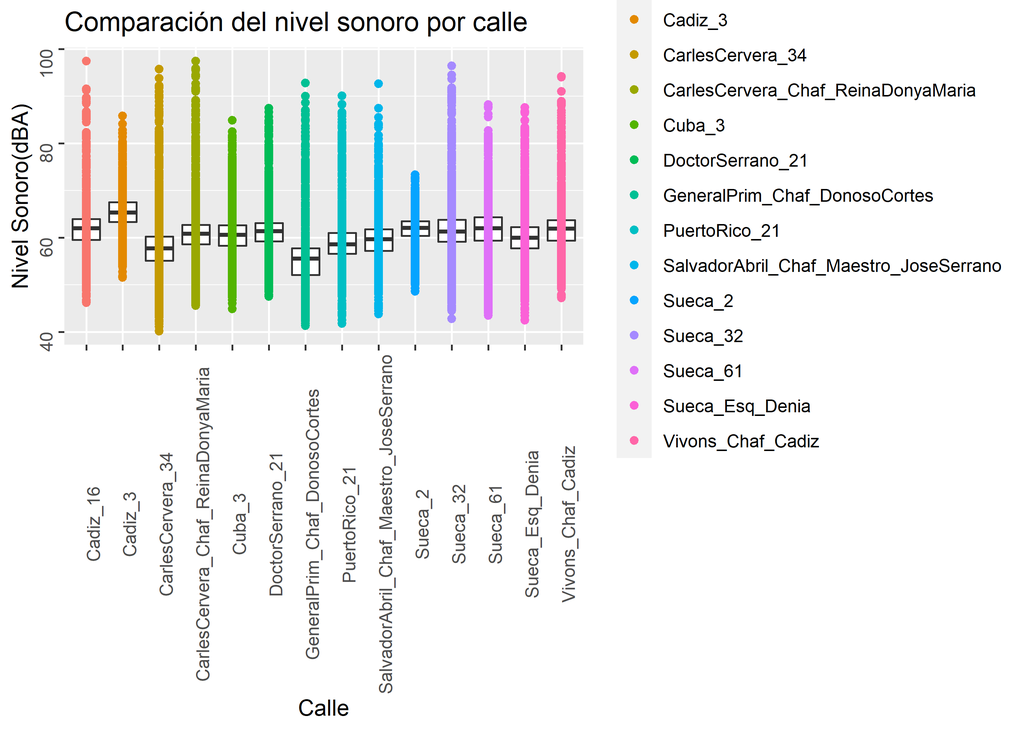

Gracias a este gráfico extraemos la siguiente información: La calle más tranquila (de media) es General Prim chaflán con Donoso Cortes. Además, la calle más ruidosa es la calle Cádiz, en concreto el número 3.

# 7 Solución a las preguntas propuestas

## 7.1 )

El DataFrame `datos` tiene 8 variables, que son id, tiempo_grabacion, year, month, day, calle, Horario, Nivel_Sonoro.

## 7.2 )

Los datos si que son fácilmente accesibles porque si observamos el Data Frame, se ve claramente y a simple vista la información.

## 7.4 )

Si que hay datos perdidos. Hemos visto que hay valores infinitos pero no hay valores faltantes (NA)

## 7.5 )

Creamos data frames seleccionando las columnas que contengan el ruido en cada franja horaria

Representamos el nivel sonoro en cada año, por meses.

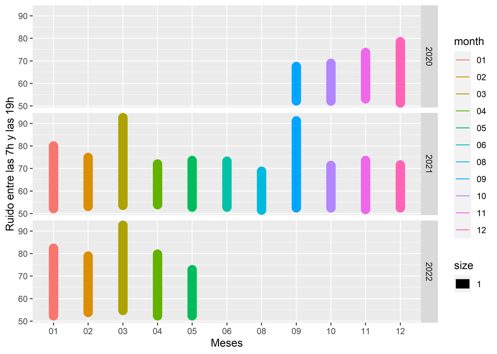

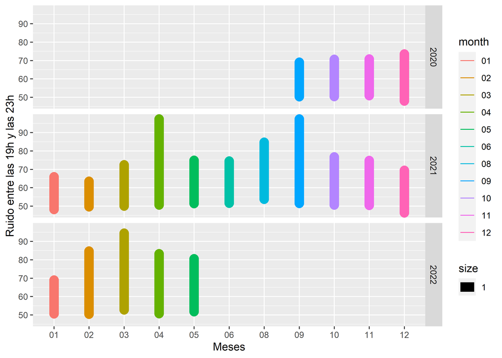

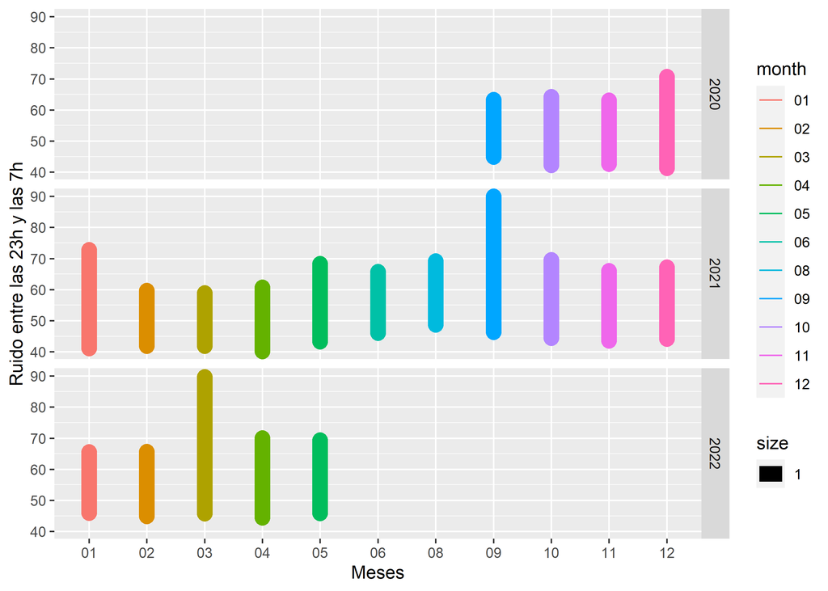

Por una parte, observamos que entre las 7:00 y las 19:00 del años 2021 y 2022 marzo es el més con más ruido pero que en el 2021 septiembre se iguala al sonido de marzo. Por otra parte, observamos que en estas horas en el 2020 el mes con más ruido era Diciembre.

Lo podemos comparar con el gráfico del ruido entre las 19:00 y las 23:00 donde vemos que el mes con más ruido es diciembre en el 2020, abril y septiembre en el 2021 y marzo en el 2022.

También vemos el gráfico del ruido entre las 23:00 y las 7:00 donde en el año 2020 sigue siendo diciembre el mes más ruidoso, en el año 2021 es septiembre seguido de enero y en el año 2022 también sigue siendo marzo.

## 7.6 )

Creamos data frames seleccionando los días en las diferentes franjas horarias en marzo

Representamos por días

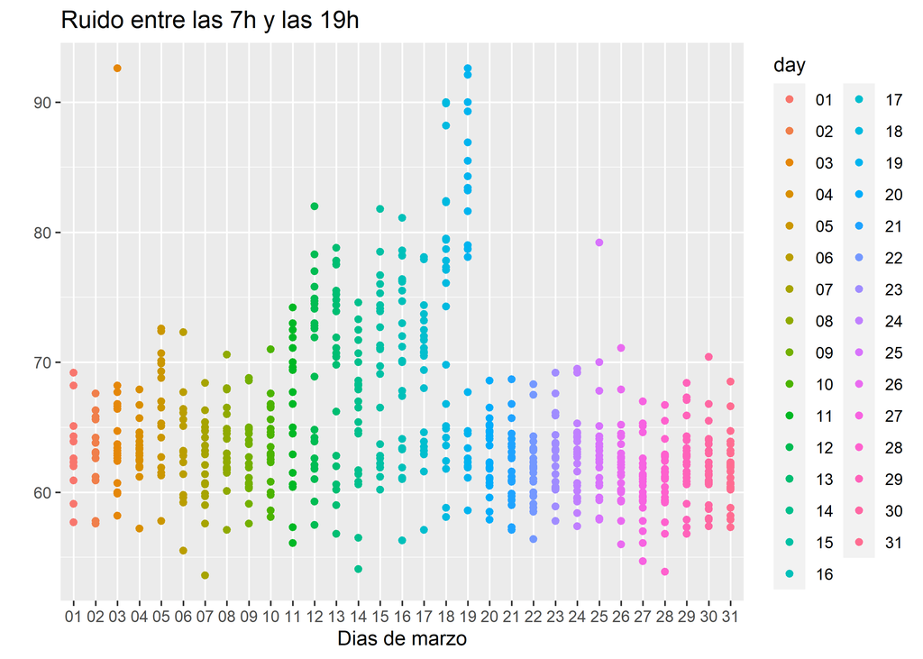

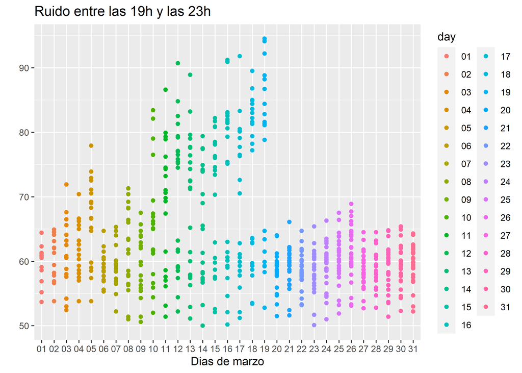

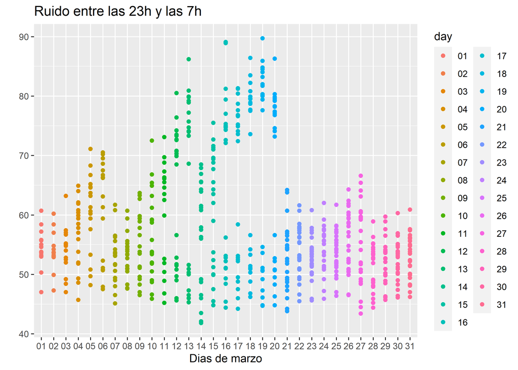

El mes que más ruido hay es Marzo, comprobamos en qué dias hay mas ruido y durante qué horas y cómo podemos ver es durante los dias de fallas que son del día 14 de marzo al 19 y el horario es entre las 19h y las 23h.

## 7.7 )

Buscamos el máximo nivel sonoro y seleccionamos la calle, la fecha y el nivel sonoro

```
# A tibble: 14 x 5
# Groups:   calle [14]
   calle                                  Nivel_Sonoro day   month year
   <fct>                                         <dbl> <fct> <fct> <fct>
 1 Cadiz_3                                        85.8 19    03    2022
 2 Cadiz_16                                       97.4 29    04    2021
 3 CarlesCervera_34                               95.7 04    09    2021
 4 CarlesCervera_Chaf_ReinaDonyaMaria             97.4 05    09    2021
 5 Cuba_3                                         84.9 19    03    2022
 6 DoctorSerrano_21                               87.4 19    03    2022
 7 GeneralPrim_Chaf_DonosoCortes                  92.8 19    03    2022
 8 PuertoRico_21                                  90.1 19    03    2022
 9 SalvadorAbril_Chaf_Maestro_JoseSerrano         92.6 03    03    2021
10 Sueca_2                                        73.3 18    06    2021
11 Sueca_32                                       96.4 19    03    2022
12 Sueca_61                                       88.2 19    03    2022
13 Sueca_Esq_Denia                                87.6 19    03    2022
14 Vivons_Chaf_Cadiz                              94.2 16    03    2022
```

Mediante la tabla, podemos observar que las calles, en este caso, con el máximo nivel sonoro son Cadiz_16 y CarlesCervera_Chaf_ReinaDonyaMaria.

Buscamos el mínimo nivel sonoro y seleccionamos la calle, la fecha y el nivel sonoro

```
# A tibble: 15 x 5
# Groups:   calle [14]
   calle                                  Nivel_Sonoro day   month year
   <fct>                                         <dbl> <fct> <fct> <fct>
 1 Cadiz_3                                        51.5 10    01    2021
 2 Cadiz_16                                       46.2 07    02    2021
 3 CarlesCervera_34                               40.1 18    04    2021
 4 CarlesCervera_Chaf_ReinaDonyaMaria             45.6 22    01    2021
 5 Cuba_3                                         44.9 31    01    2021
 6 DoctorSerrano_21                               47.5 31    01    2021
 7 GeneralPrim_Chaf_DonosoCortes                  41.3 27    12    2020
 8 PuertoRico_21                                  41.8 06    02    2021
 9 PuertoRico_21                                  41.8 13    02    2021
10 SalvadorAbril_Chaf_Maestro_JoseSerrano         43.8 10    01    2021
11 Sueca_2                                        48.6 17    01    2021
12 Sueca_32                                       42.8 17    01    2021
13 Sueca_61                                       43.5 14    03    2021
14 Sueca_Esq_Denia                                42.5 31    01    2021
15 Vivons_Chaf_Cadiz                              47.2 31    01    2021
```

## 7.8 )

Creamos una tabla en la que aparezca la media del nivel sonoro en cada año

```
# A tibble: 3 x 2
  year  Media
  <fct> <dbl>
1 2020   59.6
2 2021   60.0
3 2022   62.1
```

El año con más nivel sonoro de media es el 2022 con una media de 62.14597 dba.

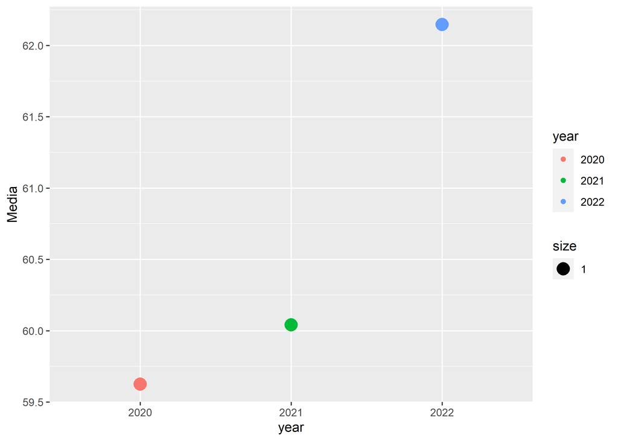

Aquí vemos gráficamente cual es la media de cada año.

## 7.9 )

Seleccionamos el horario de la tarde noche y el año 2021

Mostramos los meses que más y menos nivel sonoro han alcanzado en la tarde-noche. Además de cada uno de ellos, su máximo y mínimo ruido, y la media.

```
# A tibble: 2 x 4
  month Media Maximo Minimo
  <fct> <dbl>  <dbl>  <dbl>
1 01     61.0   78.1   53.2
2 09     67.7   95.7   56.8
```

Mostramos el resultado gráficamente

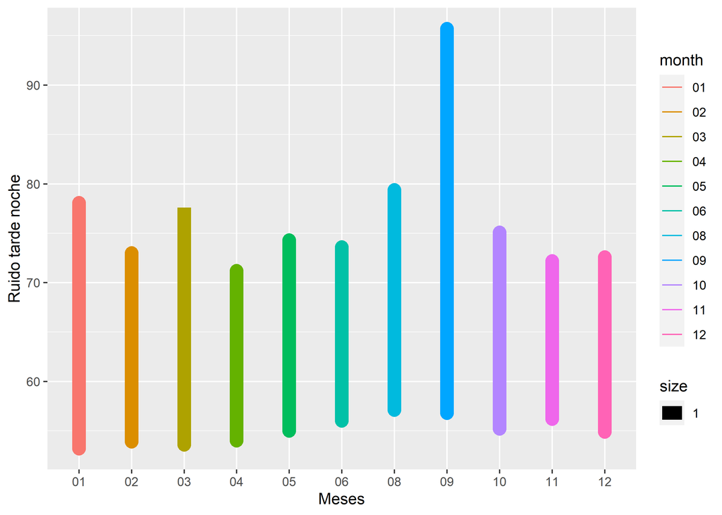

A partir de esta gráfica podemos concluir que el mes con más ruido durante la tarde y la noche es septiembre y el que menos ruido es enero.